# Proyecto Integrador

2024-11-15

# Proyecto Integrador Etapa 1

http://rmarkdown.rstudio.com

En esta etapa se realizara el analisis descriptivo de los datos

## Exploracion de datos

Al hacer una revision inicial de los datos se identifica que hay dos categorias que no caen en el estandar de los restos de los datos.

- 100 años y más: 18 295
- No especificado: 273 386

### Caso 100 años y mas

Para este caso vamos a tomar el valor como si el valor fuera solo para edades de 100 años

```r
library(readr)
original_data <- read.csv("data/original-data.csv", header=TRUE, stringsAsFactors=FALSE, fileEncoding = "ISO-8859-1")
```

Ahora actualizamos la categoria de “100 años y más” a “100 años”

```r
original_data$Total[original_data$Total == "100 años y más"] <- "100 años"
write.csv(original_data,"data/data.csv",row.names = FALSE, fileEncoding = "ISO-8859-1")
```

### Caso No especificado

Para este caso podemos tomar varios caminos, ya que no tenemos una forma certera de identificar a que edad pertenecen

1. Ignorar el dato
2. Agregar los datos a la Edad que tiene mas valores, ya que es mas probable que la mayoria de los datos pertenezcan a esta cagtegoria

Para evitar influenciar los datos, y debido a que representan muy poco porcentaje de la muestra, se eliminaran

```r
indice_de_no_especificado = original_data$Total == "No especificado"
original_data <- original_data[!indice_de_no_especificado,]
write.csv(original_data,"data/data.csv",row.names = FALSE, fileEncoding = "ISO-8859-1")
```

Ya con los datos limpios, procedemos a hacer los calculos.

## 1) Agrupacion de los datos

### 1.1 Considerar el conjunto de los datos.

Considerar el conjunto de datos en Excel de una encuesta realizada por el Instituto Nacional de Estadística y Geografía (INEGI) para obtener la información útil:

Cargando datos de data.csv

```r
library(readr)
#guess_encoding("data/data.csv")
data <- read.csv("data/data.csv", header=TRUE, stringsAsFactors=FALSE, fileEncoding = "ISO-8859-1")
```

Comprobando que los datos estan cargados correctamente

```r
head(data)
```

```
##     Total   Personas
## 1 00 años  1 812 977
## 2 01 años  1 909 958
## 3 02 años  2 041 119
## 4 03 años  2 108 406
## 5 04 años  2 174 905
## 6 05 años  2 178 901
```

```r
summary(data)
```

```
##     Total             Personas
##  Length:101         Length:101
##  Class :character   Class :character
##  Mode  :character   Mode  :character
```

Los datos de la columna “Edad” y “Personas” estan detectados como texto, pero los necesitamos como numeros.Por lo que generaremos nuevas columnas de tipo numerico, “Edad”, “NumeroDePersonas” respectivamente.

```r
data$Edad <- as.numeric(gsub(" años", "", data$Total))
data$NumDePersonas <- as.numeric(gsub(" ","",data$Personas))
write.csv(data,"updated_file.csv",row.names = FALSE)
```

Validando que la nueva columna sea de tipo numerico

```r
head(data)
```

```
##     Total   Personas Edad NumDePersonas
## 1 00 años  1 812 977    0       1812977
## 2 01 años  1 909 958    1       1909958
## 3 02 años  2 041 119    2       2041119
## 4 03 años  2 108 406    3       2108406
## 5 04 años  2 174 905    4       2174905
## 6 05 años  2 178 901    5       2178901
```

```r
summary(data)
```

```
##     Total             Personas              Edad     NumDePersonas
##  Length:101         Length:101         Min.   :  0   Min.   :  10596
##  Class :character   Class :character   1st Qu.: 25   1st Qu.: 413507
##  Mode  :character   Mode  :character   Median : 50   Median :1437771
##                                        Mean   : 50   Mean   :1244957
##                                        3rd Qu.: 75   3rd Qu.:2006341
##                                        Max.   :100   Max.   :2366318
```

### 1.2) Tabla de Frecuencias

Se agrupan los datos tomando en cuenta las edades para cada etapa del desarrollo humano tomando encuenta cada etapa del desarrollo humano, los cuales sirven para crear los intervalos y obtener las frecuencias.

- Niñes - 0 a 12
- Adolescencia - 13 a 18
- Juventud - 19 a 25
- Adultez - 26 a 60
- Vejez - 61 a 100

```r
data$RangoEdad <- cut(data$Edad,
                     breaks = c(-1, 12, 18, 25, 60, 100),
                     labels = c("Niñes (0-12)", "Adolescencia (13-18)", "Juventud (19-25)", "Adultez (26-60)", "Vejez (61-100)"),
                     right = TRUE)
```

```r
tabla_agrupada <- aggregate(NumDePersonas ~ RangoEdad, data = data, sum)
print(tabla_agrupada)
```

```
##              RangoEdad NumDePersonas
## 1         Niñes (0-12)      27462050
## 2 Adolescencia (13-18)      13093583
## 3     Juventud (19-25)      14607452
## 4      Adultez (26-60)      56768107
## 5       Vejez (61-100)      13809446
```

## 2) Realizar la descripcion de los datos agrupados

### 2.1) Obtener las medidas de tendencia central

Obtener las medidas de tendencia central: media, moda y mediana

- Toda vez que ya se tiene el software se pueden obtener las medidas de dos formas:
  - Mediante el software elegido.
  - Utilizando las fórmulas expresadas en las sesiones y/o en los materiales del curso.

Media

```r
# Obtener la marca de clase
intervalos = c(0, 12, 18, 25, 60, 100)

marcasDeClase <- (head(intervalos, -1) + tail(intervalos, -1)) / 2
print(marcasDeClase)
```

```
## [1]  6.0 15.0 21.5 42.5 80.0
```

```r
total_numero_personas = sum(tabla_agrupada$NumDePersonas)
media <- sum(tabla_agrupada$NumDePersonas * marcasDeClase)/ total_numero_personas
print(media)
```

```
## [1] 33.34353
```

Mediana

```r
# Encontrar T
T <- total_numero_personas / 2
#print(T)
# El valor de T cae en el grupo Adultes (26-60)
Li <- 26
Ls <- 60
frecuencia_acumulada <-  cumsum(tabla_agrupada$NumDePersonas)
grupo_especifico <- "Adultez (26-60)"
indice <- which(tabla_agrupada$RangoEdad == grupo_especifico)
suma_acumulada <- ifelse(indice > 1, frecuencia_acumulada[indice - 1], 0)
Fi_Minus1 <- suma_acumulada

fi <- tabla_agrupada$NumDePersonas[tabla_agrupada$RangoEdad == grupo_especifico]

ai <- Ls - Li

mediana <- Li + ((T-Fi_Minus1)/fi) * ai

print(mediana)
```

```
## [1] 30.61608
```

Moda

```r
# La moda tambien cae en el grupo de Adultes (26-60)
indice_grupo_anterior = indice - 1
indice_grupo_posterior = indice + 1

fi_Menos1 <- tabla_agrupada$NumDePersonas[indice_grupo_anterior]
fi_Mas1 <- tabla_agrupada$NumDePersonas[indice_grupo_posterior]

moda <- Li + ((fi - fi_Menos1)/((fi - fi_Menos1) + (fi - fi_Mas1))) * ai
print(moda)
```

```
## [1] 42.84062
```

Nota: Como dato interesante la mediana es menor que la Moda y la Media.

### 2.2) Obtener las medidas de dispersión: desviación estándar y varianza

- Toda vez que ya se tiene el software se pueden obtener las medidas de dos formas:
  - Mediante el software elegido.
  - Utilizando las fórmulas expresadas en las sesiones y/o en los materiales del curso.

Teniendo: * Media: 33.34 * Total de personas: 125,740,638

Varianza

```r
diferencias = marcasDeClase - media
elevando_al_quadrado = diferencias^2
multiplicando_por_frecuencia <- elevando_al_quadrado * tabla_agrupada$NumDePersonas
sumando_todo <- sum(multiplicando_por_frecuencia)
varianza = sumando_todo / total_numero_personas
print(varianza)
```

```
## [1] 491.5478
```

Desviacion Estandar

```r
desviacion_standard <- sqrt(varianza)
print(desviacion_standard)
```

```
## [1] 22.17088
```

### 2.3) Obtener el histograma de frecuencias, ojiva y polígono de frecuencias.

- Utilizar el software seleccionado para obtener:
  - Polígono de frecuencias
  - Ojiva
  - Histograma

Poligono de frecuencias

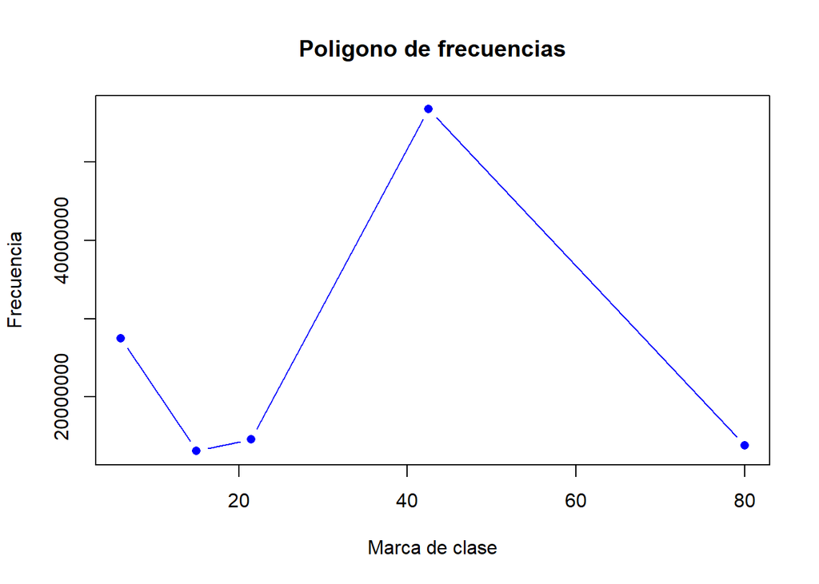

```r
# Evitar notación científica
options(scipen = 999)
plot(marcasDeClase, tabla_agrupada$NumDePersonas,type = "b", pch=16, col="blue",xlab = "Marca de clase", ylab = "Frecuencia", main = "Poligono de frecuencias")
```

Ojiva

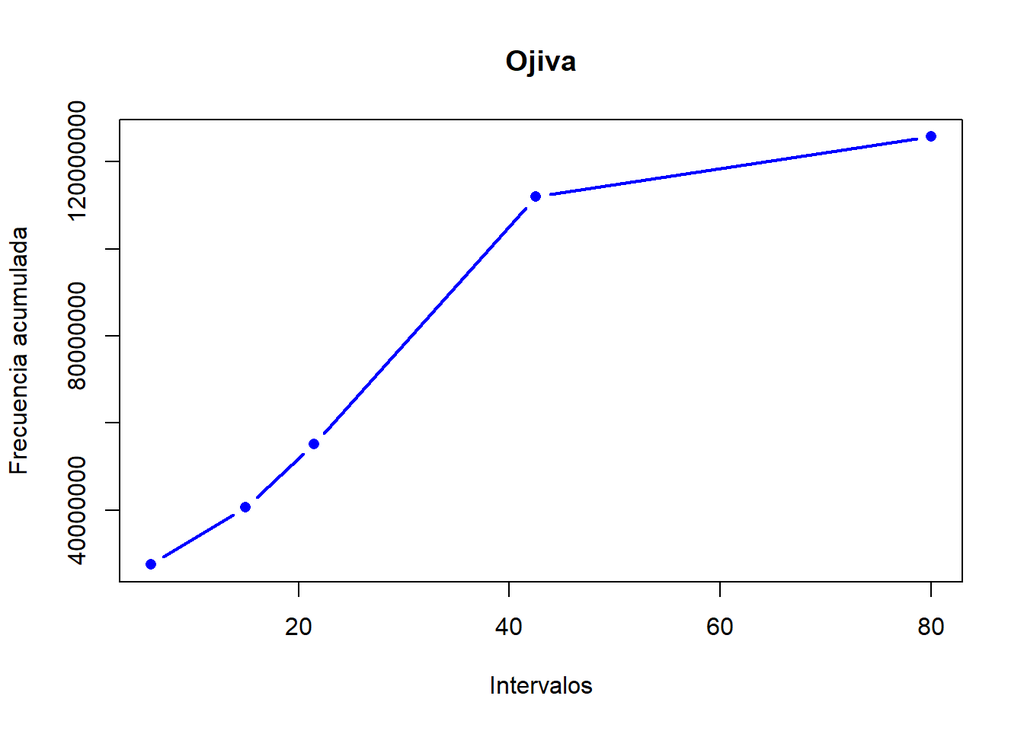

```r
tabla_agrupada$NumDePersonasAcumuladas <- cumsum(tabla_agrupada$NumDePersonas)

plot(marcasDeClase, tabla_agrupada$NumDePersonasAcumuladas, type = "b", col = "blue", pch=16, lwd = 2 , xlab = "Intervalos", ylab = "Frecuencia acumulada", main = "Ojiva")
```

Histograma

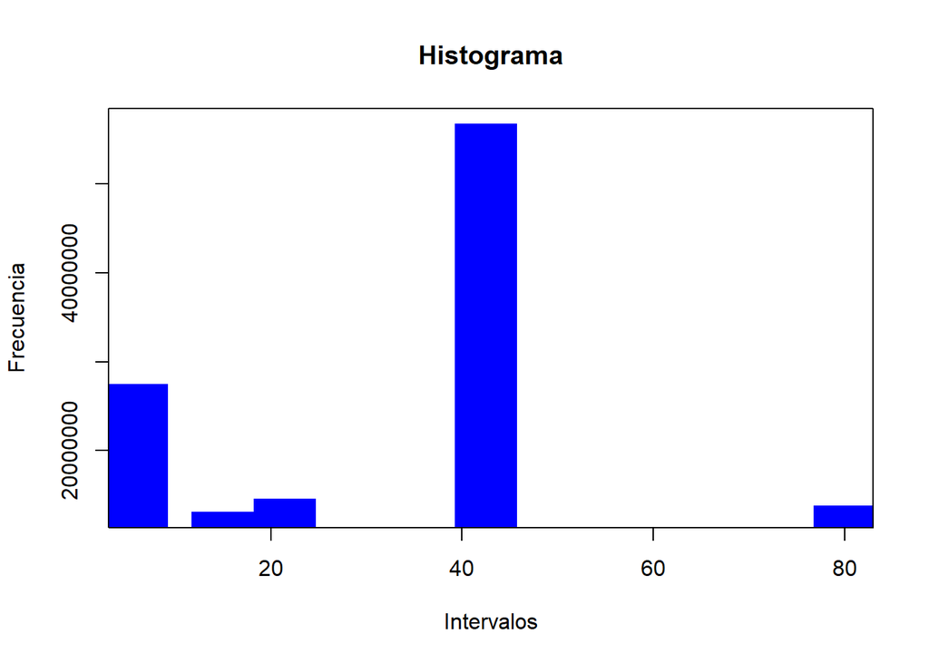

```r
plot(marcasDeClase, tabla_agrupada$NumDePersonas, type = "h", lwd=45, lend=1, col= "blue", xlab = "Intervalos", ylab="Frecuencia", main = "Histograma")
```

### 2.4) Obtener probabilidades de valores con respecto a alguna distribución de probabilidad

- Elegir dados los datos, una distribución de probabilidad, preferentemente la normal para trabajar.
- Elegir para cada etapa de la vida (niñez, adolescencia, juventud, adultez, vejez) un valor ( por ejemplo, en adultez la edad del equipo, en niñez la edad de su hijo, etc.)
  - Utilizar las unidades Z para calcular dada la media y la varianza, la probabilidad de que la edad media de la etapa sea menor al valor extremo de la etapa dado esto es P(edad media<=Valor extremo de la etapa). Por ejemplo el valor medio de la niñez sea de 10,000 y el valor total de la etapa de niñez sea 23000.